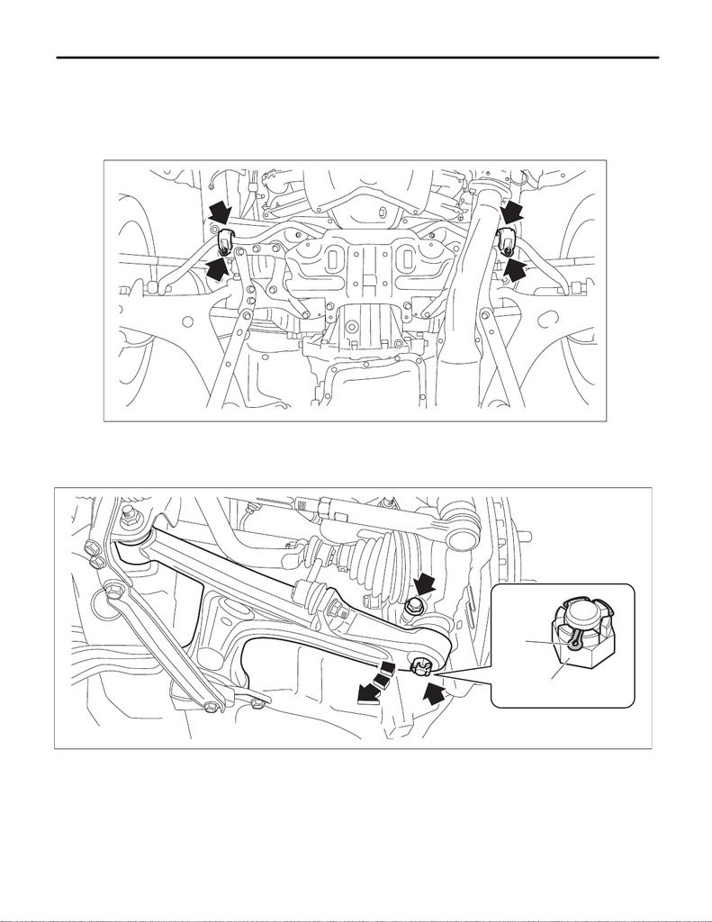

FS-33

Front Ball Joint

FRONT SUSPENSION

6. Front Ball Joint

A: REMOVAL

1) Lift up the vehicle, and then remove the front wheels.

2) Remove the under cover - front. <Ref. to EI-21, REMOVAL, Front Under Cover.>

3) Remove the clamp - stabilizer bushing on the left and right sides.

4) Remove the ball joint assembly.

(1) Pull out the cotter pin (a), and remove the castle nut (b).

(2) Pull down the front arm assembly, and remove the ball stud.

(3) Remove the bolt from the housing assembly - front axle.

(4) Pull out the ball joint assembly.

FS-00663

FS-00677

(a)

(b)

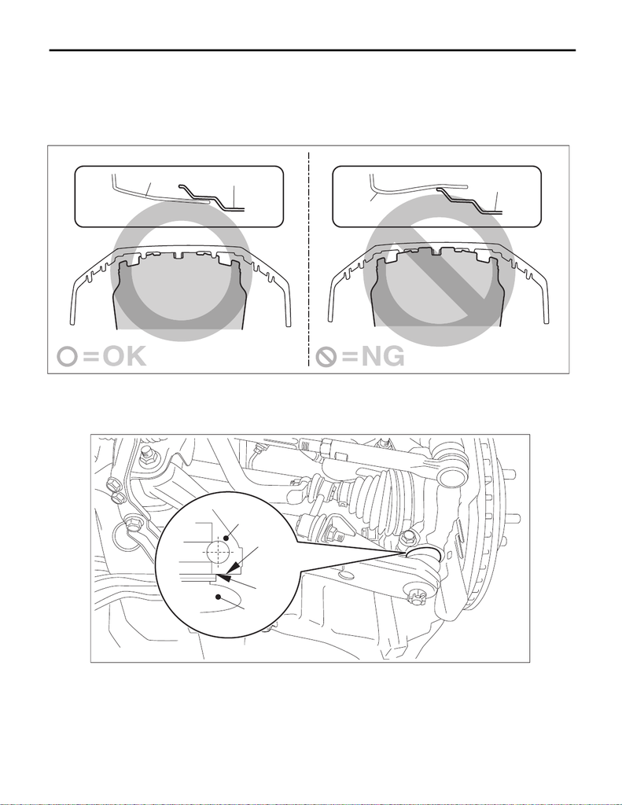

FS-34

Front Ball Joint

FRONT SUSPENSION

B: INSTALLATION

CAUTION:

• For parts which are not reusable, always use new parts.

• Do not apply grease to the tapered portion of ball stud.

• Install the under cover - front so that the front end of the under cover (b) comes inside the bumper

face - front (a).

1) Install the ball joint assembly.

CAUTION:

Before tightening, make sure the bottom surface of the housing assembly - front axle and the

stepped section of ball joint are in contact.

Tightening torque:

50 N·m (5.1 kgf-m, 36.9 ft-lb)

(a) Bottom surface of housing ASSY -

front axle

(c) Housing ASSY - front axle (d) Ball joint ASSY

EI-04291

(b)

(a)

(b)

(a)

FS-00508

(a)

(b)

(c)

(d)

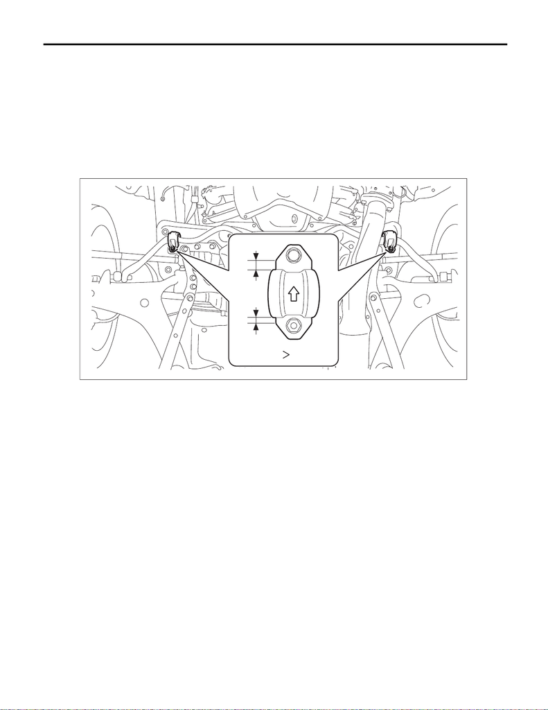

FS-35

Front Ball Joint

FRONT SUSPENSION

2) Connect the ball joint assembly to the front arm assembly.

NOTE:

When tightening the castle nut, tighten the castle nut to the specified torque first, then tighten it further but

within 60° until the hole in the ball stud is aligned with a slot in castle nut.

Tightening torque:

39 N·m (4.0 kgf-m, 28.8 ft-lb)

3) Insert a new cotter pin and secure the castle nut.

4) Install the clamp - stabilizer bushing.

CAUTION:

Install the clamp - stabilizer bushing with the arrow mark facing the front of the vehicle.

Tightening torque:

25 N·m (2.5 kgf-m, 18.4 ft-lb)

5) Install the under cover - front. <Ref. to EI-22, INSTALLATION, Front Under Cover.>

6) Install the front wheels.

Tightening torque:

120 N·m (12.2 kgf-m, 88.5 ft-lb)

FS-00656

A

B

AB

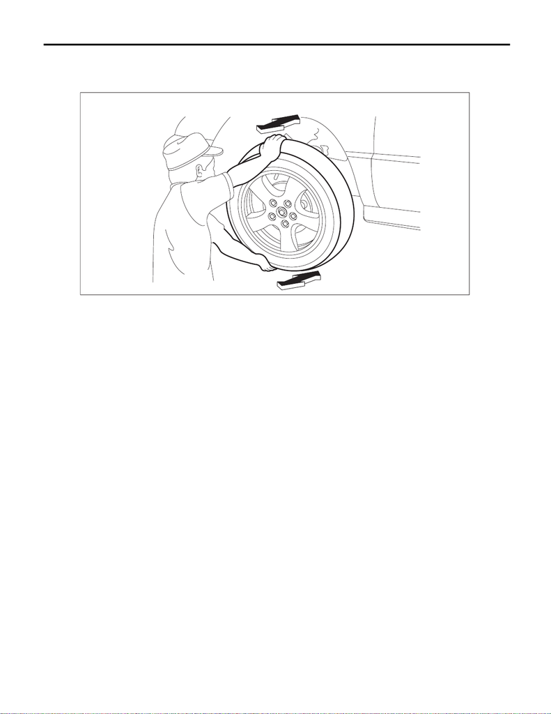

FS-36

Front Ball Joint

FRONT SUSPENSION

C: INSPECTION

1) Check that there is no play by moving the upper and lower portions of front tire in an axial direction with

the brake pedal depressed.

• Play exists. → Replace the ball joint assembly. <Ref. to FS-33, REMOVAL, Front Ball Joint.>

2) Check that there is no play by moving the upper and lower portions of front tire in an axial direction with

the brake pedal released.

• Play exists. → Check the hub unit COMPL - front axle. <Ref. to DS-31, INSPECTION, Front Hub Unit

Bearing.>

3) Replace the ball joint assembly if the dust cover is damaged when visually inspecting the dust cover.

FS-00510